# Satellite(Sentinel2) Image analysis

# Lesson Goals

In this lesson, i will show you how to analysis satellite data with different bands and i will demonstrate to you how to calculate Normalized Difference Vegetation Index (NDVI)

# Prerequests

1. the below mentioned libraries
2. i used QGIS for visulisation purpose so you can also grab it from internet(opensource)

```python
#import required libraries
import rasterio
from rasterio import plot
import matplotlib.pyplot as plt
%matplotlib inline
```

```python
import os
from glob import glob
import matplotlib.pyplot as plt
import rasterio as rio
from rasterio.plot import plotting_extent
import geopandas as gpd
import earthpy as et
import earthpy.spatial as es
import earthpy.plot as ep
```

```python
#import bands as separate 1 band raster
imagePath = '../Sentinel2/GRANULE/L2A_T37PDL_A028117_20201109T074203/IMG_DATA/R10m/'
band2 = rasterio.open(imagePath+'T37PDL_20201109T074131_B02_10m.jp2', driver='JP2OpenJPEG') #blue
band3 = rasterio.open(imagePath+'T37PDL_20201109T074131_B03_10m.jp2', driver='JP2OpenJPEG') #green
band4 = rasterio.open(imagePath+'T37PDL_20201109T074131_B04_10m.jp2', driver='JP2OpenJPEG') #red
band8 = rasterio.open(imagePath+'T37PDL_20201109T074131_B08_10m.jp2', driver='JP2OpenJPEG') #nir
```

```python
#number of raster bands
band4.count
```

```
1
```

```python
#number of raster columns
band4.width
```

```
10980
```

```python
#number of raster rows
band4.height
```

```
10980
```

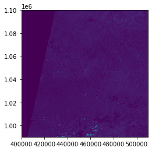

```python
#plot band
plot.show(band4)
```

```python
#type of raster byte
band4.dtypes[0]
```

```
'uint16'
```

```python
#raster sytem of reference
band4.crs
```

```
CRS.from_epsg(32637)
```

```python
#raster transform parameters
band4.transform
```

```
Affine(10.0, 0.0, 399960.0,
       0.0, -10.0, 1100040.0)
```

```python
#raster values as matrix array
band4.read(1)
```

```
array([[   0,    0,    0, ..., 1626, 1394,  911],
       [   0,    0,    0, ..., 1380, 1154, 1022],
       [   0,    0,    0, ..., 1013,  679,  625],
       ...,
       [   0,    0,    0, ...,  923,  774,  714],
       [   0,    0,    0, ...,  970,  774,  767],
       [   0,    0,    0, ..., 1008,  895,  952]], dtype=uint16)
```

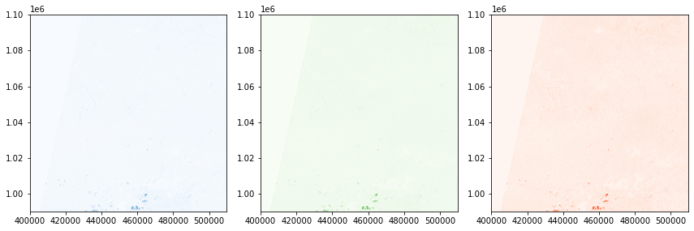

```python
#multiple band representation
fig, (ax1, ax2, ax3) = plt.subplots(1, 3, figsize=(12, 4))
plot.show(band2, ax=ax1, cmap='Blues')
plot.show(band3, ax=ax2, cmap='Greens')
plot.show(band4, ax=ax3, cmap='Reds')
fig.tight_layout()
```

```python
#export true color image
trueColor = rasterio.open('./Output/SentinelTrueColor2.tiff','w',driver='Gtiff',
                         width=band4.width, height=band4.height,
                         count=3,
                         crs=band4.crs,
                         transform=band4.transform,
                         dtype=band4.dtypes[0]
                         )
trueColor.write(band2.read(1),3) #blue
trueColor.write(band3.read(1),2) #green
trueColor.write(band4.read(1),1) #red
trueColor.close()
```

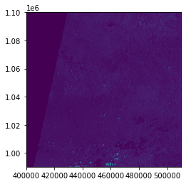

```python
src = rasterio.open(r"./Output/SentinelTrueColor2.tiff", count=3)
plot.show(src)
```

```python
#export false color image
falseColor = rasterio.open('./Output/SentinelFalseColor.tiff', 'w', driver='Gtiff',
                          width=band2.width, height=band2.height,
                          count=3,
                          crs=band2.crs,
                          transform=band2.transform,
                          dtype='uint16'
                         )
falseColor.write(band3.read(1),3) #Blue
falseColor.write(band4.read(1),2) #Green
falseColor.write(band8.read(1),1) #Red
falseColor.close()
```

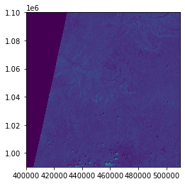

```python
src1 = rasterio.open(r"./Output/SentinelFalseColor.tiff", count=3)
plot.show(src1)
```

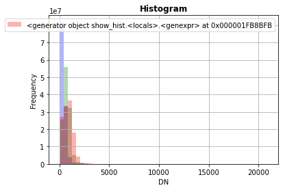

```python
#generate histogram
trueColor = rasterio.open('./Output/SentinelTrueColor2.tiff')
plot.show_hist(trueColor, bins=50, lw=0.0, stacked=False, alpha=0.3, histtype='stepfilled', title="Histogram")
```

## Converting dataset band to RGB

```python
# create an RGB image
with rio.open('RGB.tiff', 'w', driver='Gtiff', width=band4.width, height=band4.height, count=3, crs=band4.crs, transform=band4.transform, dtype=band4.dtypes[0]) as rgb:
    rgb.write(band2.read(1),1)
    rgb.write(band3.read(1), 2)
    rgb.write(band4.read(1),3)
    rgb.close()
```

## Create NDVI

Calculating Normalized Difference Vegetation Index (NDVI) is an important indicator to assess the presence/absence of green vegetation from the satellite images. To calculate the NDVI, you need Red band and Near-Infrared Band (NIR). Different satellite images assign different numbers for these bands. Sentinel Images have red in 4th band and NIR in the 8th band. The formula for NDVI calculation is: nir - red /(nir + red)

```python
#read band4 and band8 as arrays
red = band4.read()
nir = band8.read()
```

```python
# Calculate NDVI
ndvi = (nir.astype(float)-red.astype(float))/(nir+red)
```

```python
# Write the NDVI image

meta = band4.meta
meta.update(driver='GTiff')
meta.update(dtype=rasterio.float32)

with rasterio.open('NDVI.tif', 'w', **meta) as dst:
    dst.write(ndvi.astype(rasterio.float32))
```

# Further reading

1.Advanced Analysis of Satellite Data Using Python [link](https://www.esri.com/content/dam/esrisites/en-us/events/conferences/2020/developer-summit/advanced-analysis-of-satellite-imagery-using-python.pdf).

2.A Python Book: Beginning Python, Advanced Python, and Python Exercises [link](http://www.davekuhlman.org/python_book_01.pdf).

3.Satellite Image Classification with Deep Learning [link](https://arxiv.org/ftp/arxiv/papers/2010/2010.06497.pdf)

## 7. Conclusion

The work described in this notebook is shows how to analyze satellite images. Specifically:

- how to know import different bands of satellite images
- how to understand the property of the image
- how to create true and false color
- how to calculate NDVI

# Next Step

There is still much room to further study like adding different layers to the existing one to recognize patters in vegetation.